# Data Visualization

R.T. Dananjana

9/4/2020

```r
library(tidyverse)
library(readxl)
library(magrittr)
library(ggplot2)
library(tm)
library(wordcloud)
```

I called the dataset which is partially cleaned and did further cleaning

```r
my.data<-read.csv("dataset.csv",header = TRUE)
```

```r
#Separe Skills and Other information columns in to seperate  dataframes.

skills<-my.data[,c(17:78)]
other<-my.data[,-c(17:78)]
```

```r
#reordered the skills columns according to colsum
skills_order<-skills[,order(decreasing=TRUE,colSums(skills))]
```

```r
#new dataframe
new.data<-cbind(other,skills_order)
```

Education Qualification column cleaning

```r
##Assignning NA's
new.data[new.data=="Not_define"]<-NA
new.data[new.data=="Not_mentioned"]<-NA
new.data[new.data=="NA"]<-NA
new.data[new.data=="not mention"]<-NA
new.data[new.data=="not mentioned"]<-NA
```

```r
#Converting all the Educational qualifications to lower case letters
Adjusted_Education<-str_to_lower(new.data$Educational_qualifications)

#removing punctuation marks
punc_removed<-gsub("[[:punct:]]", " ", Adjusted_Education)


#Qualification is not metioned.

Not_defined_quali<-punc_removed[str_detect(punc_removed,"(NA)|(not mention)")]
length(Not_defined_quali)#in 93 rows qualification is not defined
```

```
[1] 93
```

```r
#Qualification mentioned
Defined_quali<-punc_removed[!punc_removed%in%Not_defined_quali]
length(Defined_quali)#in 332 rows qualification is defined.
```

```
[1] 332
```

```r
# Minimum education qualification is a Bachelor degree


Bachelor_Jobs<-Defined_quali[str_detect(Defined_quali,"(bsc\\s*|bs\\s*)|(bachelor\\s*|bachelors\\s*|bachelor's\\s*)")]
length(Bachelor_Jobs)#138
```

```
[1] 138
```

```r
non_bach<-Defined_quali[!str_detect(Defined_quali,"(bsc\\s*|bs\\s*)|(bachelor\\s*|bachelors\\s*|bachelor's\\s*)")]
length(non_bach)#194
```

```
[1] 194
```

```r
#minimum educational qualification is a MSc
Master_Jobs<-non_bach[str_detect(non_bach,"(master)|(ms)|(masters)")]
length(Master_Jobs)#52
```

```
[1] 52
```

```r
non_msc<-non_bach[!str_detect(non_bach,"(master)|(ms)|(masters)")]
length(non_msc)
```

```
[1] 142
```

```r
#minimum educational qualification is a Phd
phd_jobs<-non_msc[str_detect(non_msc,"(phd)|(ph.)")]
length(phd_jobs)#33
```

```
[1] 33
```

```r
#Other Qualification
other<-non_msc[!str_detect(non_msc,"(phd)|(ph.)")]
length(other)#109
```

```
[1] 109
```

Then, created a new grouping variable for educational qualification named as Edu_Category.

```r
edu<-data.frame(new.data,punc_removed)#new dataframe with adjusted edu qualifications



B1 <- edu[edu$punc_removed%in% Not_defined_quali,] %>% mutate(Edu_Category= rep("NA", nrow(.)))
dim(B1)
```

```
[1] 93 81
```

```r
B2 <- edu[edu$punc_removed %in% Bachelor_Jobs,] %>% mutate(Edu_Category= rep("Min_Bsc", nrow(.)))
dim(B2)
```

```
[1] 138  81
```

```r
B3 <- edu[edu$punc_removed %in% Master_Jobs,] %>% mutate(Edu_Category= rep("min_Master", nrow(.)))
dim(B3)
```

```
[1] 52 81
```

```r
B4 <- edu[edu$punc_removed %in% phd_jobs,] %>% mutate(Edu_Category= rep("Phd", nrow(.)))
dim(B4)
```

```
[1] 33 81
```

```r
B5 <- edu[edu$punc_removed %in% other,] %>% mutate(Edu_Category= rep("other", nrow(.)))
dim(B5)
```

```
[1] 109  81
```

```r
new_edu<-rbind(B1,B2,B3,B4,B5)
dim(new_edu)
```

```
[1] 425  81
```

Then created a new dataframe.

```r
drop<-c("punc_removed","Job_Titles")
Cleaned_data<-new_edu[,!(names(new_edu) %in% drop)]
dim(Cleaned_data)
```

```
[1] 425  79
```

```r
write.csv(Cleaned_data,file = "clead data.csv")
```

Then the country column will be cleaned by using the Cleaned_data file stored before.

```r
Location<-Cleaned_data$Location
unique(Location)#53 unique locations
```

```
 [1] Canada               Singapore            India
 [4] Australia            USA                  Japan
 [7] US                   Russia               Colombo
[10] UK                   Germany              San Fransico
[13] Chicago              New York             Cambridge
[16] SL                   China                Malaysia
[19] Sri Lanka            <NA>                 London
[22] Brazil               San Mateo            Arlington
[25] Chevy Chase          Mclean               Austin
[28] Minneapolis          Seattle              California
[31] ES                   Hungary              NC
[34] Colorado             Boston               Kenya
[37] Singaore             United Arab Emirates Carfiff
[40] Italy                Salt Lake City       Montgomery Country
[43] Boise                Washington           Mountain View
[46] New Kensington       New zealand          IE
[49] Philippines          OR                   Africa
[52] RO                   England
52 Levels: Africa Arlington Austin Australia Boise Boston ... Washington
```

```r
# renaming SL to Sri Lanka,England and UK to united kingdom,USA and US to united stated
Location<-str_replace_all(Location, "SL", "Sri Lanka")
Location <-str_replace_all(Location, "England","United Kingdom" )
Location<-str_replace_all(Location, "USA", "United States")
Location<- str_replace_all(Location, "US", "United States")
Location<-str_replace_all(Location, "UK", "United Kingdom")


 #making all the entries to lower case
 lower<-str_to_lower(Location)
 unique(lower)
```

```
 [1] "canada"               "singapore"            "india"
 [4] "australia"            "united states"        "japan"
 [7] "russia"               "colombo"              "united kingdom"
[10] "germany"              "san fransico"         "chicago"
[13] "new york"             "cambridge"            "sri lanka"
[16] "china"                "malaysia"             NA
[19] "london"               "brazil"               "san mateo"
[22] "arlington"            "chevy chase"          "mclean"
[25] "austin"               "minneapolis"          "seattle"
[28] "california"           "es"                   "hungary"
[31] "nc"                   "colorado"             "boston"
[34] "kenya"                "singaore"             "united arab emirates"
[37] "carfiff"              "italy"                "salt lake city"
[40] "montgomery country"   "boise"                "washington"
[43] "mountain view"        "new kensington"       "new zealand"
[46] "ie"                   "philippines"          "or"
[49] "africa"               "ro"
```

```r
# Call an external file with countries names in the world
country_name_data<-read_excel("Countries.xlsx")
country_name_data<-str_to_lower(country_name_data$Country)

#Extracting the countries in our dataset which match with the country names in the external file
country_list<-lower[lower%in%country_name_data]
length(country_list)
```

```
[1] 370
```

```r
#There are 370 entries with a country in it already
unique(country_list)#20 unique countries in our dataset are already filled
```

```
 [1] "canada"               "singapore"            "india"
 [4] "australia"            "united states"        "japan"
 [7] "russia"               "united kingdom"       "germany"
[10] "sri lanka"            "china"                "malaysia"
[13] "brazil"               "hungary"              "kenya"
[16] "united arab emirates" "italy"                "new zealand"
[19] "philippines"          "africa"
```

```r
#Extracting the locations in our dataset which is not a country.
no_country<-lower[!lower%in%country_name_data]
length(no_country)#there are 55 entries which are not inside the country list
```

```
[1] 55
```

```r
unique(no_country)#There are 30 unique locations we havnt still identified
```

```
 [1] "colombo"            "san fransico"       "chicago"
 [4] "new york"           "cambridge"          NA
 [7] "london"             "san mateo"          "arlington"
[10] "chevy chase"        "mclean"             "austin"
[13] "minneapolis"        "seattle"            "california"
[16] "es"                 "nc"                 "colorado"
[19] "boston"             "singaore"           "carfiff"
[22] "salt lake city"     "montgomery country" "boise"
[25] "washington"         "mountain view"      "new kensington"
[28] "ie"                 "or"                 "ro"
```

```r
#Calling an external list of cities and countries
city_country<-read.csv("worldcities.csv",header = TRUE)
city<-str_to_lower(city_country$city)
country<-str_to_lower(city_country$country)
city_country<-data.frame(city,country)


city_country_match<-city_country[city_country$city%in%no_country,]

colnames(city_country_match)<-c("New_location","Country")
city_country_match<-city_country_match[!duplicated(city_country_match[,c("New_location")]),]
```

```r
#Making a new data frame with column lower
new_data3<-data.frame(Cleaned_data,lower)
colnames(new_data3)<-c(colnames(Cleaned_data),"New_location")

#Data we do not need to match
data_not_to_match<-new_data3[new_data3$New_location%in%country_list,]
dim(data_not_to_match)
```

```
[1] 370  80
```

```r
#Data we need to match
new_data_to_match<-new_data3[new_data3$New_location%in%no_country,]
dim(new_data_to_match)
```

```
[1] 55 80
```

```r
#Joining the country to the data with unidentified location
left.join<-left_join(new_data_to_match,city_country_match)
dim(left.join)
```

```
[1] 55 81
```

```r
#Making a new data frame
drop<-c("New_location")
left.join<-left.join[,!(names(left.join) %in% drop)]
names(left.join)[length(names(left.join))]<-"New_location"

with_new_location<-rbind(data_not_to_match,left.join)





sum(is.na(with_new_location$New_location))
```

```
[1] 20
```

```r
d2<-data.frame(with_new_location$Location,with_new_location$New_location)
unique(d2)
```

```
    with_new_location.Location with_new_location.New_location
1                       Canada                         canada
5                    Singapore                      singapore
8                        India                          india
9                    Australia                      australia
10                         USA                  united states
13                       Japan                          japan
16                          US                  united states
23                      Russia                         russia
27                          UK                 united kingdom
30                     Germany                        germany
38                          SL                      sri lanka
47                       China                          china
68                    Malaysia                       malaysia
73                   Sri Lanka                      sri lanka
```

[output cut: 39 more lines]

```r
# Finally thecleaned dataset is stored to the Cleaned_data_new
Cleaned_data_new<-with_new_location
```

## Visualizations

### Panel One

- Overview of the dataset.
- Indroducing the objective of designing this dashboard.
- Providing the names of the developers.

### Panel Two

In here it’s good if we provide a summary of job categories we are refering, through the dashboard we design.

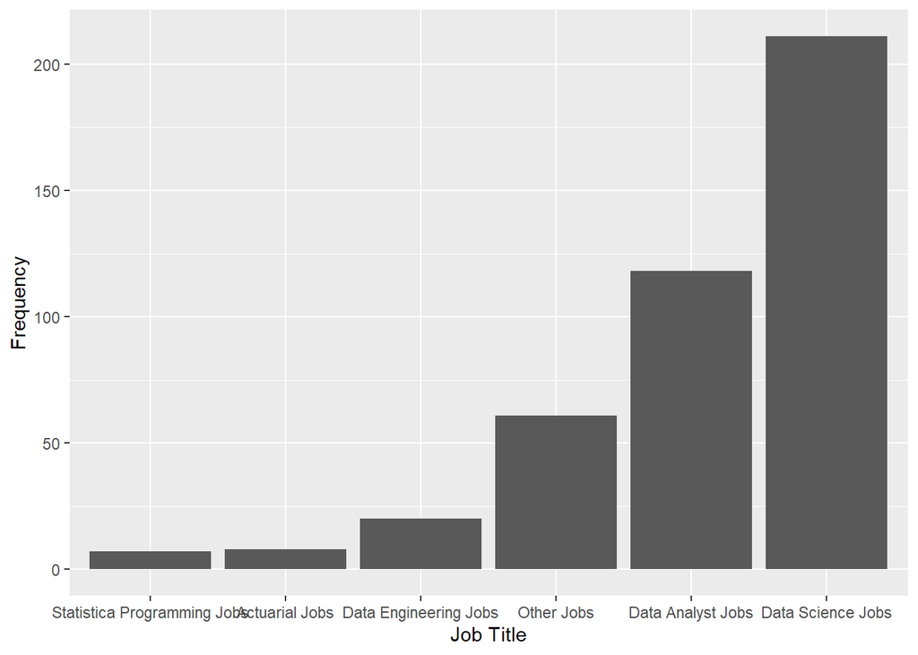

```r
# box plot for Job_Category
Jobs_frequency<-data.frame(table(Cleaned_data_new$Job_Category))


Jobs_frequency$Var1 <- factor(Jobs_frequency$Var1,levels = Jobs_frequency$Var1[order(Jobs_frequency$Freq)])
ggplot(Jobs_frequency, aes(Var1, Freq)) +
  geom_bar(stat = "identity")+labs(y="Frequency",x="Job Title")
```

Then, when the viewer click on his/her desired job category, he/she will directed to the companies and the locations of the relevant job category is available. For example, let’s consider someone is interested in Data Engineering Jobs, then he/she can view the companies and locations where the Data Engineering Jobs are available.

```r
DS<-subset(Cleaned_data_new[,c(15,80)], Cleaned_data_new$Job_Category == "Data Science Jobs")%>% unique()

DE<-subset(Cleaned_data_new[,c(15,80)], Cleaned_data_new$Job_Category == "Data Engineering Jobs")%>% unique()
DE
```

```
                                               Company  New_location
38                                    snaphunt pte ltd         india
41                            kensho technologies, inc united states
42             live connections,hyderabad/secunderabad         india
43                                    live connections         india
147                                chenega corporation united states
148 wisconsin physicians service insurance corporation united states
149                                      sound transit united states
150   axiata digital labs, colombo, western, sri lanka     sri lanka
151                                axiata digital labs     sri lanka
372                                                sdk        canada
374                           john keells holdings plc     sri lanka
375                                  snaphunt pte. ltd     sri lanka
222                                            workday united states
427                               john keells holdings     sri lanka
```

```r
Data_Analyst<-subset(Cleaned_data_new[,c(15,80)], Cleaned_data_new$Job_Category == "Data Analyst Jobs")%>% unique()

Stat_Programmer<-subset(Cleaned_data_new[,c(15,80)], Cleaned_data_new$Job_Category == "Statistica Programming Jobs")%>% unique()
Stat_Programmer
```

```
                                           Company New_location
72                                         covance        china
73  br raysoft global pvt ltd, bengaluru/bangalore        india
206                                    novartis ag        china
277                      everest clinical research        china
410                                       paraexel        china
```

```r
Actuarial<-subset(Cleaned_data_new[,c(15,80)], Cleaned_data_new$Job_Category == "Actuarial Jobs")%>% unique()
Actuarial
```

```
                                  Company New_location
74                                    aig     malaysia
75                               deloitte     malaysia
207    american international group, inc.        china
208                        prudential plc     malaysia
209    sun life malaysia assurance berhad     malaysia
411 axa group operations malaysia sdn bhd     malaysia
412                             axa group     malaysia
413                        spark acturial    sri lanka
```

```r
Other<-subset(Cleaned_data_new[,c(15,80)], Cleaned_data_new$Job_Category == "Other Jobs")%>% unique()
```

### Panel 3

Job_Category vs Statistical Software requirement graph

```r
# Considered the statistical softwares as Python, R,SAS, SPSS, Matlab based on their order on column sum


Cleaned_data_new$Statistical_software <- paste(Cleaned_data_new$Python,Cleaned_data_new$R,Cleaned_data_new$SAS,Cleaned_data_new$SPSS,Cleaned_data_new$MAtlab,sep = "::")

unique(Cleaned_data_new$Statistical_software)
```

```
 [1] "0::0::0::0::0" "1::0::0::0::0" "1::1::0::0::0" "0::1::0::0::0"
 [5] "1::0::0::0::1" "1::1::1::0::0" "1::1::1::0::1" "1::1::0::1::0"
 [9] "1::1::0::0::1" "0::0::1::0::0" "1::1::1::1::0" "1::0::1::0::0"
[13] "1::1::0::1::1" "0::1::1::0::0" "0::1::1::0::1" "0::0::1::1::0"
[17] "0::1::1::1::1" "0::1::0::1::0" "0::0::0::1::0" "1::1::1::1::1"
[21] "0::1::1::1::0" "0::1::0::0::1" "1::0::1::0::1"
```

```r
d2 <- Cleaned_data_new$Statistical_software %>% table() %>% as.data.frame()
names(d2) <- c('Statistical_software', 'Frequency')
d2 <- d2[order(d2$Frequency, decreasing = F),]

#Categorize the Statistical Software requirements as R & python, R,Pyhon &SAS ,No needing of Statstical software and others

Cleaned_data_new$Statistical_software[Cleaned_data_new$Statistical_software=="1::1::0::0::0"] <-"Python & R"
Cleaned_data_new$Statistical_software[Cleaned_data_new$Statistical_software=="0::0::0::0::0"] <-"No Statistical softwares"
Cleaned_data_new$Statistical_software[Cleaned_data_new$Statistical_software=="1::0::0::0::0"] <-"Python"
Cleaned_data_new$Statistical_software[Cleaned_data_new$Statistical_software=="1::1::1::0::0"] <-"Python,R & SAS"
Cleaned_data_new$Statistical_software[Cleaned_data_new$Statistical_software=="0::1::0::0::0" |Cleaned_data_new$Statistical_software=="1::1::0::1::1"| Cleaned_data_new$Statistical_software=="1::0::0::0::1"| Cleaned_data_new$Statistical_software=="1::1::1::0::1" | Cleaned_data_new$Statistical_software=="1::1::0::1::0"| Cleaned_data_new$Statistical_software=="0::1::1::1::0"| Cleaned_data_new$Statistical_software=="0::1::0::1::0"| Cleaned_data_new$Statistical_software=="0::1::0::0::1"| Cleaned_data_new$Statistical_software=="0::1::1::0::1"| Cleaned_data_new$Statistical_software=="1::0::1::0::0"| Cleaned_data_new$Statistical_software=="1::1::1::1::1"| Cleaned_data_new$Statistical_software=="0::0::1::1::0"| Cleaned_data_new$Statistical_software=="1::1::1::1::0"| Cleaned_data_new$Statistical_software=="1::0::1::0::1"| Cleaned_data_new$Statistical_software=="0::0::0::1::0"| Cleaned_data_new$Statistical_software=="1::1::0::0::1"| Cleaned_data_new$Statistical_software=="0::1::1::1::1"| Cleaned_data_new$Statistical_software=="0::0::1::0::0"| Cleaned_data_new$Statistical_software=="0::1::1::0::0"| Cleaned_data_new$Statistical_software=="0::0::0::1::1"] <-"Other"

unique(Cleaned_data_new$Statistical_software)
```

```
[1] "No Statistical softwares" "Python"
[3] "Python & R"               "Other"
[5] "Python,R & SAS"
```

```r
d2 <- Cleaned_data_new$Statistical_software %>% table() %>% as.data.frame()
names(d2) <- c('Statistical_software', 'Frequency')
d2 <- d2[order(d2$Frequency, decreasing = F),]

d2
```

```
      Statistical_software Frequency
5           Python,R & SAS        26
3                   Python        89
2                    Other        91
1 No Statistical softwares        95
4               Python & R       124
```

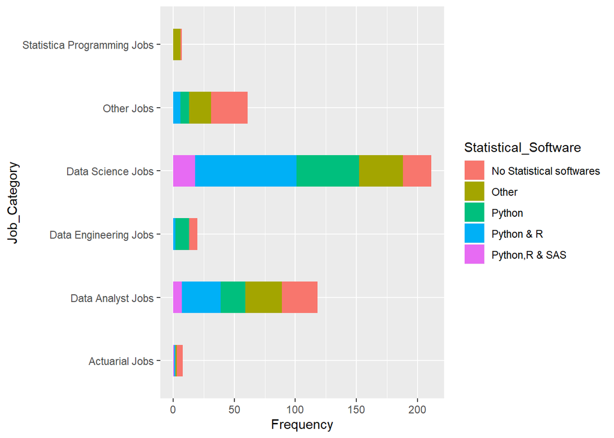

```r
Tab2<-as.data.frame(table(Cleaned_data_new$Job_Category,Cleaned_data_new$Statistical_software ))
names(Tab2)<-c("Job_Category","Statistical_Software","Frequency")




ggplot(Tab2, aes(y=Frequency, x=Job_Category,fill=Statistical_Software)) +
  geom_bar(stat = "identity",width = 0.5)+coord_flip()
```

Job_Category vs Educational Qualifications_Category Graph

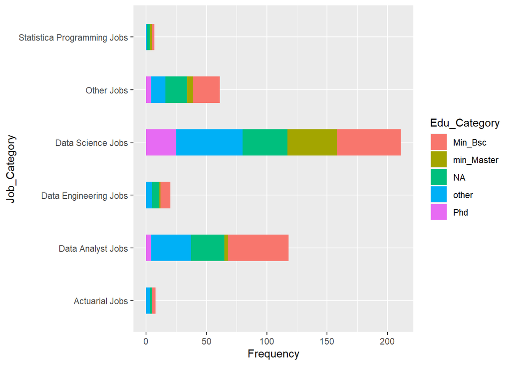

```r
#Two way table for Job_Category and Minimum Education Qualifications required

Tab<-as.data.frame(table(Cleaned_data_new$Job_Category,Cleaned_data_new$Edu_Category ))
names(Tab)<-c("Job_Category","Edu_Category","Frequency")
new_tab<-Tab[order(Tab$Frequency,decreasing = F),]


ggplot(new_tab, aes(y=Frequency, x=Job_Category,fill=Edu_Category)) +
  geom_bar(stat = "identity",width = 0.5)+coord_flip()
```

### Panel 4

Word Cloud for Knowledge in column

```r
Knowledge<-Cleaned_data_new$Knowledge_in
sum(is.na.data.frame(Knowledge))
```

```
[1] 170
```

```r
Knowledge<-Knowledge[!is.na(Knowledge)] #removing NAs
length(Knowledge)
```

```
[1] 255
```

```r
corpus<-Corpus(VectorSource(Knowledge))
corpus[[1]][1]
```

```
$content
[1] "Text mining"
```

```r
#Convert the text to lower

corpus<-tm_map(corpus,content_transformer(tolower))

#Remove numbers

corpus<-tm_map(corpus,removeNumbers)

#Remove punctuations

corpus<-tm_map(corpus,removePunctuation)

#Remove unwanted words

corpus<-tm_map(corpus,removeWords,c("and","for","knowledge","etc","with","using","the","like","from","such","including","well","other","excellent"))

tdm<-TermDocumentMatrix(corpus)
m<-as.matrix(tdm)
v<-sort(rowSums(m),decreasing = TRUE)
length(v)
```

```
[1] 662
```

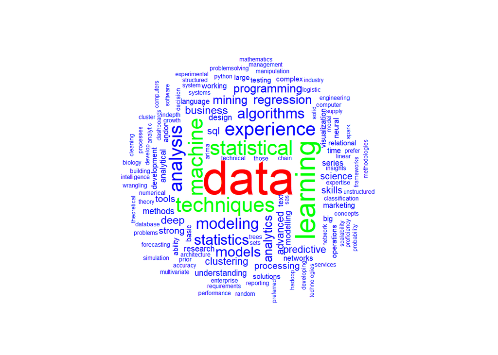

```r
d<-data.frame(word=names(v),freq=v)

wordcloud(d$word,d$freq,random.order = FALSE,rot.per = 0.3,scale = c(4,0.365),colors = c("blue","green","red"),max.words = 450)
```